# Data Analysis - Red Wine

Xiaofan Zhang

December 22, 2018

========================================================

Introduction

In this project, I will analyze the Red Wine data and try to understand which variables are responsible for the quality of the wine.

The tidy data set contains 1,599 red wines with 11 variables on the chemical properties of the wine. At least 3 wine experts rated the quality of each wine, providing a rating between 0 (very bad) and 10 (very good)

First of all, I will take a look at the structure and summary of the dataset.

```
## [1] 1599   13
```

```
##  [1] "X"                    "fixed.acidity"        "volatile.acidity"
##  [4] "citric.acid"          "residual.sugar"       "chlorides"
##  [7] "free.sulfur.dioxide"  "total.sulfur.dioxide" "density"
## [10] "pH"                   "sulphates"            "alcohol"
## [13] "quality"
```

```
## 'data.frame':    1599 obs. of  13 variables:
##  $ X                   : int  1 2 3 4 5 6 7 8 9 10 ...
##  $ fixed.acidity       : num  7.4 7.8 7.8 11.2 7.4 7.4 7.9 7.3 7.8 7.5 ...
##  $ volatile.acidity    : num  0.7 0.88 0.76 0.28 0.7 0.66 0.6 0.65 0.58 0.5 ...
##  $ citric.acid         : num  0 0 0.04 0.56 0 0 0.06 0 0.02 0.36 ...
##  $ residual.sugar      : num  1.9 2.6 2.3 1.9 1.9 1.8 1.6 1.2 2 6.1 ...
##  $ chlorides           : num  0.076 0.098 0.092 0.075 0.076 0.075 0.069 0.065 0.073 0.071 ...
##  $ free.sulfur.dioxide : num  11 25 15 17 11 13 15 15 9 17 ...
##  $ total.sulfur.dioxide: num  34 67 54 60 34 40 59 21 18 102 ...
##  $ density             : num  0.998 0.997 0.997 0.998 0.998 ...
##  $ pH                  : num  3.51 3.2 3.26 3.16 3.51 3.51 3.3 3.39 3.36 3.35 ...
##  $ sulphates           : num  0.56 0.68 0.65 0.58 0.56 0.56 0.46 0.47 0.57 0.8 ...
##  $ alcohol             : num  9.4 9.8 9.8 9.8 9.4 9.4 9.4 10 9.5 10.5 ...
##  $ quality             : int  5 5 5 6 5 5 5 7 7 5 ...
```

```
##        X          fixed.acidity   volatile.acidity  citric.acid
##  Min.   :   1.0   Min.   : 4.60   Min.   :0.1200   Min.   :0.000
##  1st Qu.: 400.5   1st Qu.: 7.10   1st Qu.:0.3900   1st Qu.:0.090
##  Median : 800.0   Median : 7.90   Median :0.5200   Median :0.260
##  Mean   : 800.0   Mean   : 8.32   Mean   :0.5278   Mean   :0.271
##  3rd Qu.:1199.5   3rd Qu.: 9.20   3rd Qu.:0.6400   3rd Qu.:0.420
##  Max.   :1599.0   Max.   :15.90   Max.   :1.5800   Max.   :1.000
##  residual.sugar     chlorides       free.sulfur.dioxide
##  Min.   : 0.900   Min.   :0.01200   Min.   : 1.00
##  1st Qu.: 1.900   1st Qu.:0.07000   1st Qu.: 7.00
##  Median : 2.200   Median :0.07900   Median :14.00
##  Mean   : 2.539   Mean   :0.08747   Mean   :15.87
##  3rd Qu.: 2.600   3rd Qu.:0.09000   3rd Qu.:21.00
##  Max.   :15.500   Max.   :0.61100   Max.   :72.00
##  total.sulfur.dioxide    density             pH          sulphates
##  Min.   :  6.00       Min.   :0.9901   Min.   :2.740   Min.   :0.3300
##  1st Qu.: 22.00       1st Qu.:0.9956   1st Qu.:3.210   1st Qu.:0.5500
##  Median : 38.00       Median :0.9968   Median :3.310   Median :0.6200
##  Mean   : 46.47       Mean   :0.9967   Mean   :3.311   Mean   :0.6581
##  3rd Qu.: 62.00       3rd Qu.:0.9978   3rd Qu.:3.400   3rd Qu.:0.7300
##  Max.   :289.00       Max.   :1.0037   Max.   :4.010   Max.   :2.0000
##     alcohol         quality
##  Min.   : 8.40   Min.   :3.000
##  1st Qu.: 9.50   1st Qu.:5.000
##  Median :10.20   Median :6.000
##  Mean   :10.42   Mean   :5.636
##  3rd Qu.:11.10   3rd Qu.:6.000
##  Max.   :14.90   Max.   :8.000
```

Some observations from the summary: 1. The quality of wine ranges from 3 to 8 with a median of 6. 2. The amount of total sulfur dioxide varies greatly. 3. Some wines have no citric acid, which adds ‘freshness’ and flavor to them.

# Univariate Plots Section

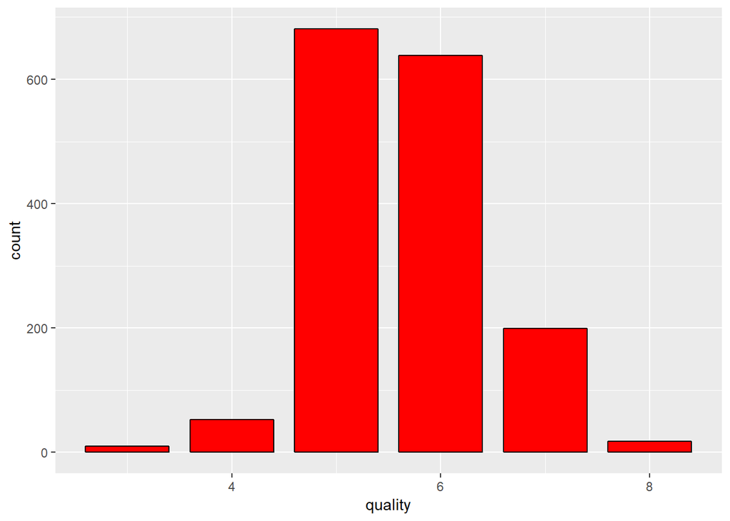

This plot confirms the prior observation that most wine samples have quality rating of 5, 6 or 7. We don’t have a lot of data very good quality wine (rating of 8 and higher) and very bad quality wine (rating of 4 or lower).

Now, I would like to create plot for each of the chemical properties to study their distribution.

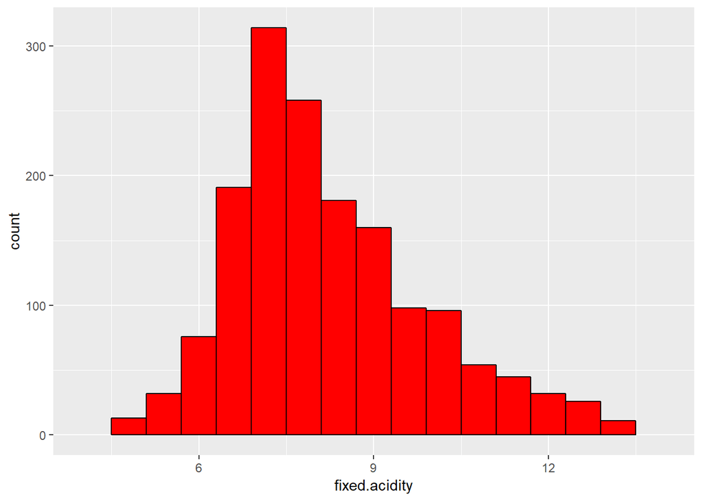

This plot is slightly positively skewed and has a peak between 7 and 8.

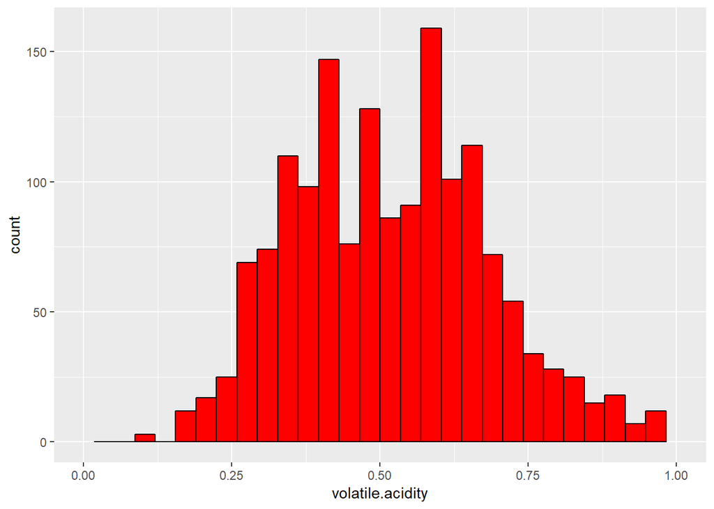

After removing missing values and outliers, the graph seems to be normally distributed with the majority of volatile acidity falling between 0.25 and 0.75.

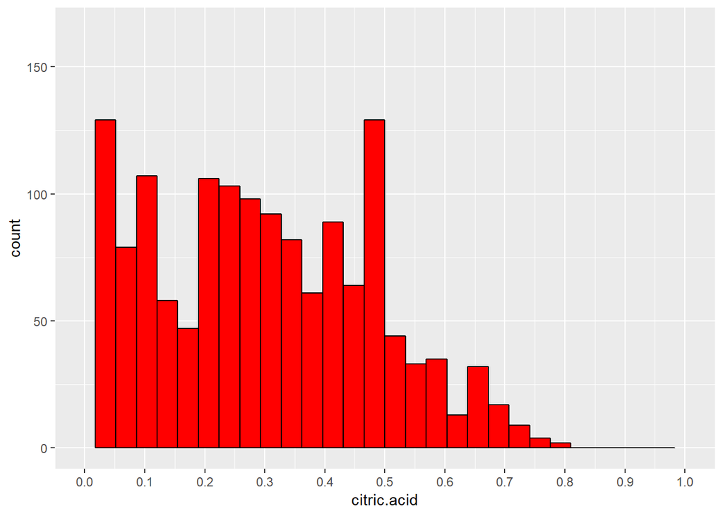

The majority of wines have citric acid values that fall between 0 and 0.7.

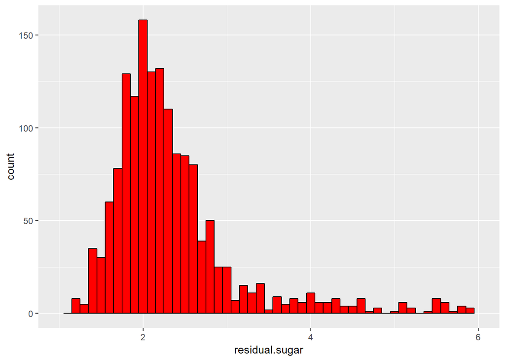

The graph is positively skewed and the peak occurs at the residual sugar value of 2.

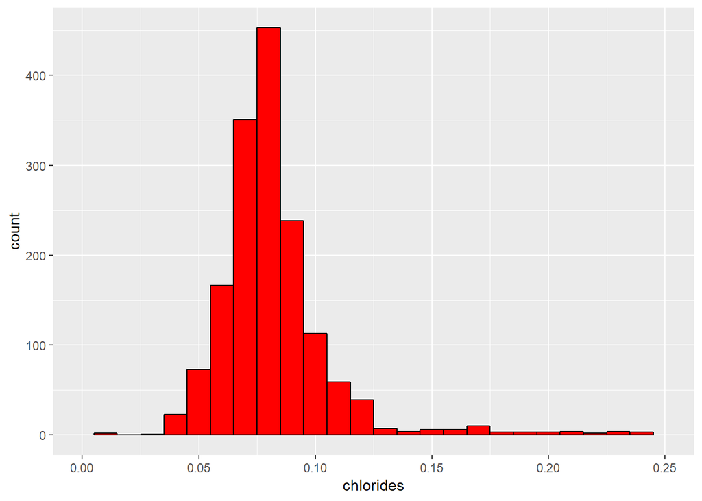

The peak occrus around 0.075 and the plot containts some outliers on the right side.

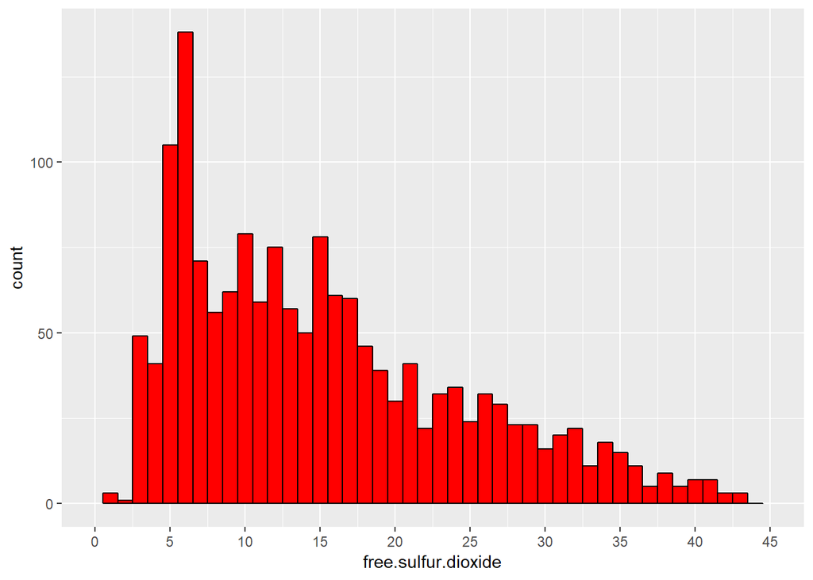

The plot is positively skewed and there is a peak around 6 on the x-axis.

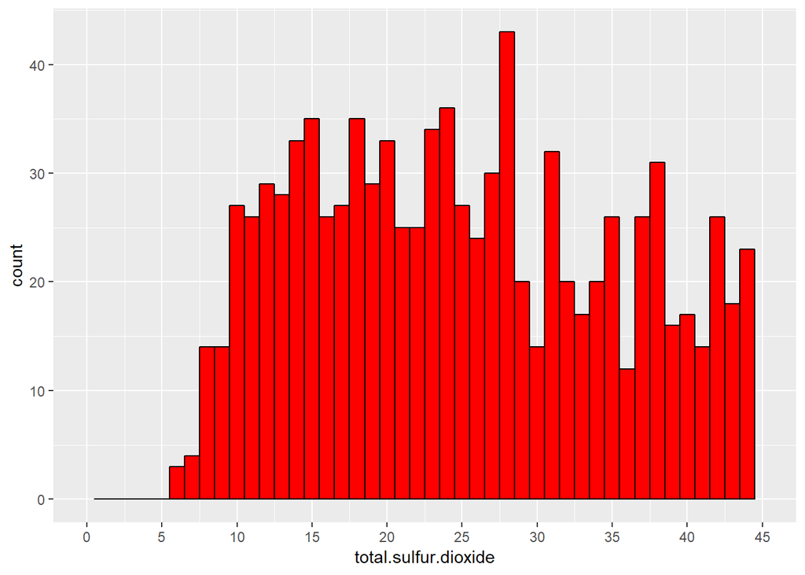

The plot has a peak around 28 and is not normally distributed.

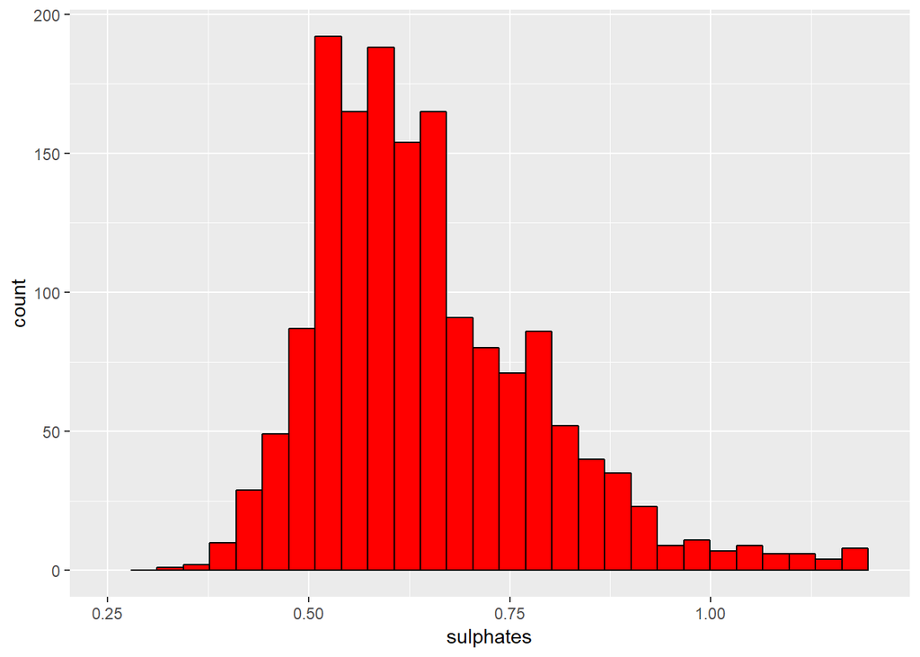

After excluding the outliers, the plot has a peak around 0.6 and is normally distributed.

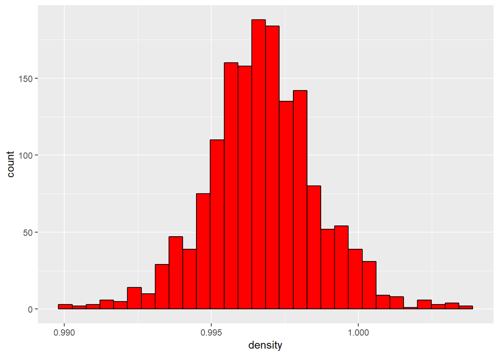

Density has a small range between 0.9901 and 1.0037. The distribution seems normal.

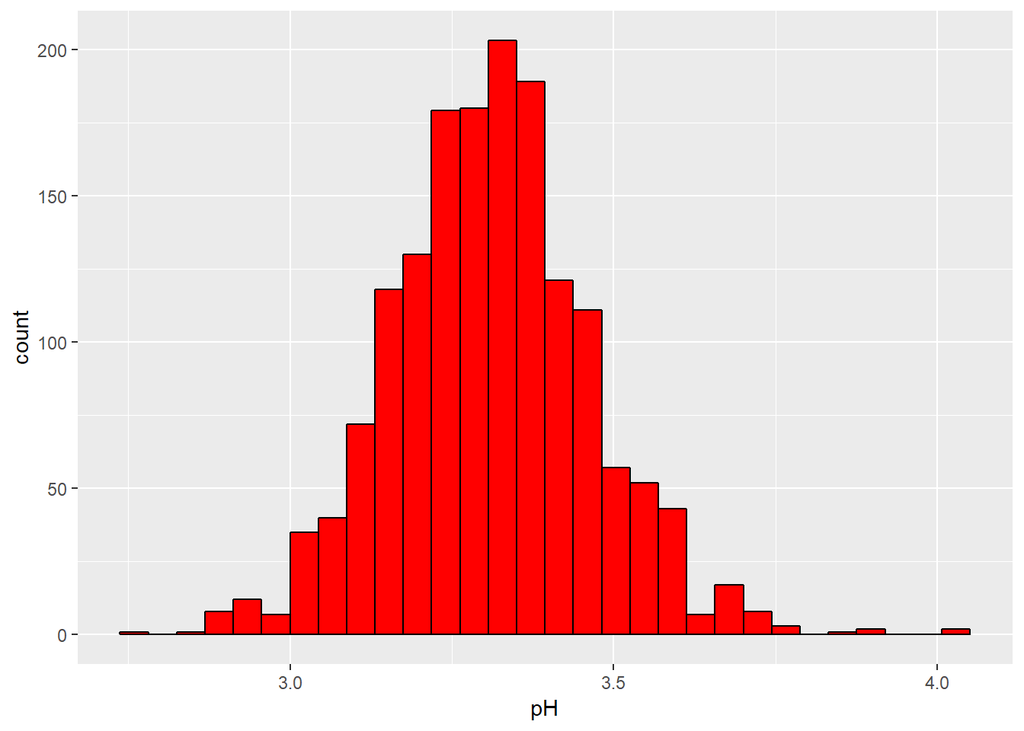

The peak occrus around the pH value of 3.3 and the distribution seems normal.

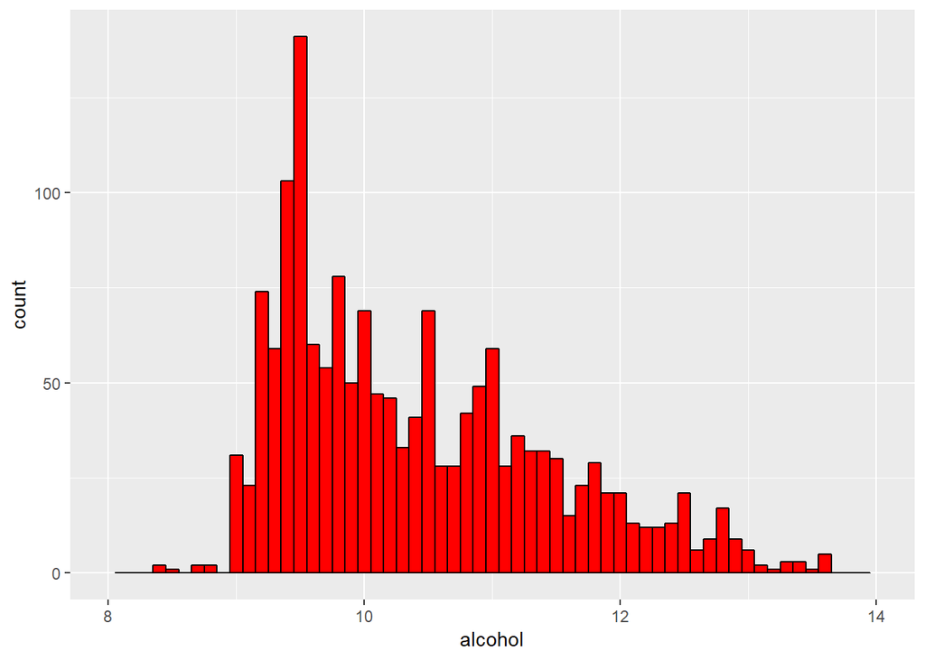

The graphs above are not enough to identify the variables which affect the wine quality.

# Univariate Analysis

This dataset contains 1599 observations of red wines with 11 variables on the chemical properties of the wine. The main feature of interest is quality. I would like to find out which chemicals influence the quality of red wine. I didn’t create any new variables from existing variables in the dataset. Most distributions are considered either normal or slightly positively skewed. Therefore, I didn’t change the form of the data.

# Bivariate Plots Section

In this section, I will first explore the correlations between the variables and then to figure out the variables that need further investigation.

Let’s begin by removing the variable X as it is not useful in the exploration of correlations.

```
##
## ---------------------------------------------------------------------------
##           &nbsp;            fixed.acidity   volatile.acidity   citric.acid
## -------------------------- --------------- ------------------ -------------
##     **fixed.acidity**             1             -0.2561        **0.6717**
##
##    **volatile.acidity**        -0.2561             1           **-0.5525**
##
##      **citric.acid**         **0.6717**       **-0.5525**           1
##
##     **residual.sugar**         0.1148           0.001918         0.1436
##
##       **chlorides**            0.09371           0.0613          0.2038
##
##  **free.sulfur.dioxide**       -0.1538          -0.0105         -0.06098
##
##  **total.sulfur.dioxide**      -0.1132          0.07647          0.03553
##
##        **density**            **0.668**         0.02203        **0.3649**
##
##           **pH**             **-0.683**          0.2349        **-0.5419**
##
##       **sulphates**             0.183            -0.261        **0.3128**
##
##        **alcohol**            -0.06167          -0.2023          0.1099
##
##        **quality**             0.1241         **-0.3906**        0.2264
## ---------------------------------------------------------------------------
##
## Table: Table continues below
##
##
## ------------------------------------------------------------------------------
##           &nbsp;            residual.sugar   chlorides    free.sulfur.dioxide
## -------------------------- ---------------- ------------ ---------------------
##     **fixed.acidity**           0.1148        0.09371           -0.1538
##
##    **volatile.acidity**        0.001918        0.0613           -0.0105
##
##      **citric.acid**            0.1436         0.2038          -0.06098
```

[output cut: 66 more lines]

```
##
##  **free.sulfur.dioxide**     0.05166      -0.06941      -0.05066
##
##  **total.sulfur.dioxide**    0.04295       -0.2057       -0.1851
##
##        **density**            0.1485     **-0.4962**     -0.1749
##
##           **pH**             -0.1966       0.2056       -0.05773
##
##       **sulphates**             1          0.09359       0.2514
##
##        **alcohol**           0.09359          1        **0.4762**
##
##        **quality**            0.2514     **0.4762**         1
## -------------------------------------------------------------------
```

Now let’s look at the visual representation of the correlations.

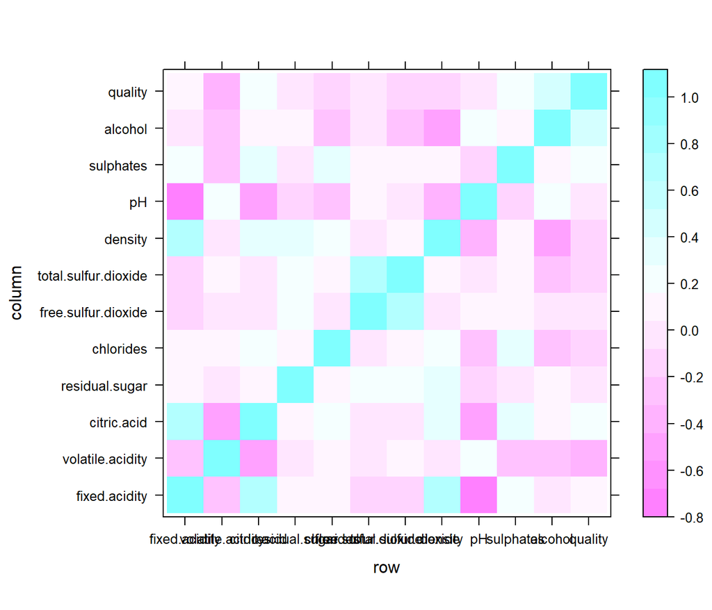

Both the matrix and the plot confirm that the variables which are strongly correlated to quality are acohol and volatile acidity. The correlation coefficients are 0.4762 and -0.3906.

In the following section, we will be creating bivariate plots to visualize the relationships between quality and the chemical properties.

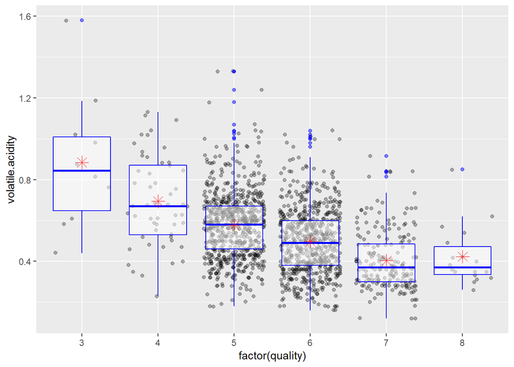

From the plot above, it is evident that higher quality wine tends to have lower amount of volatile acidity.

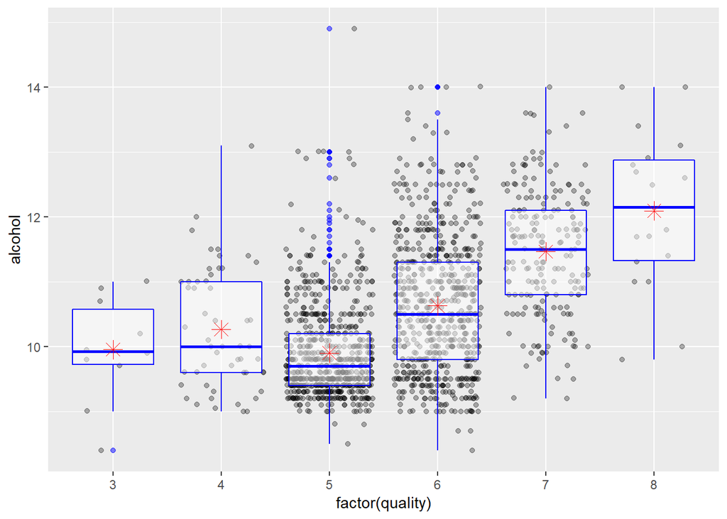

This plot desmonstrates better wines have higher percentage of alcohol.

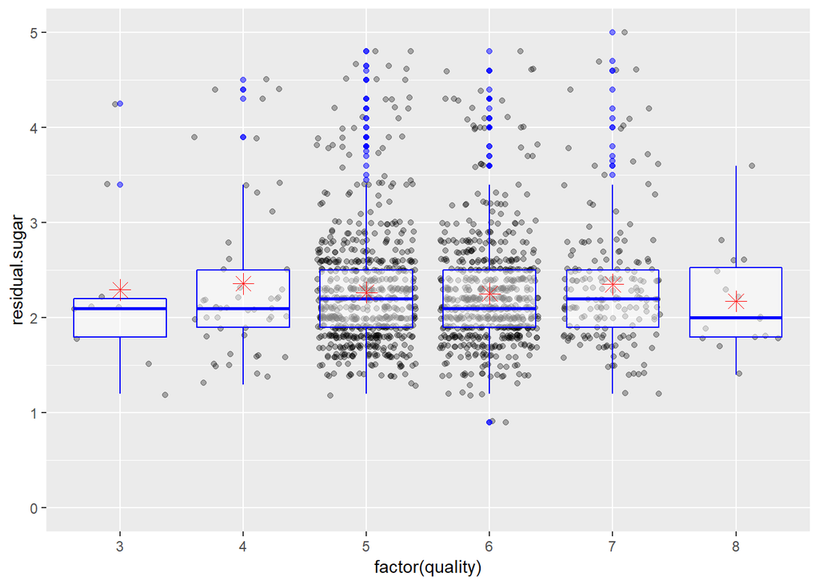

There is no observable relationship between residual sugar and the quality of wine.

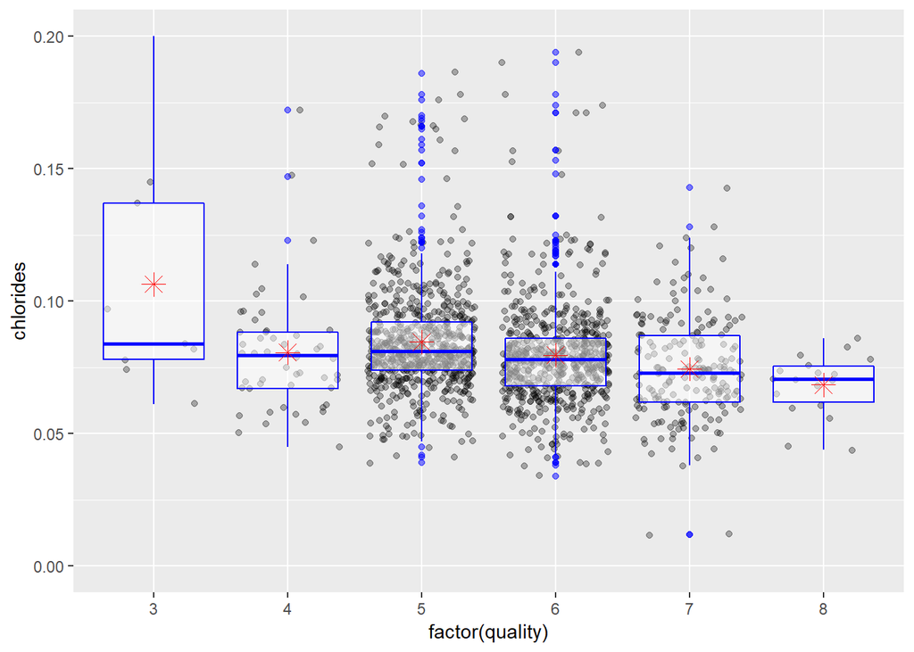

It seems the quality of wine is negatively correlated to the level of chlorides.However the relationship is weak.

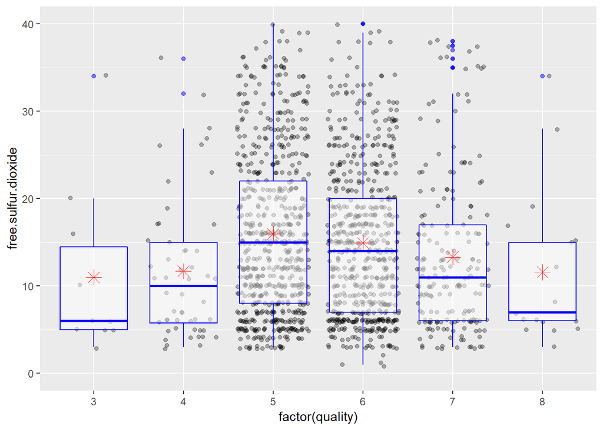

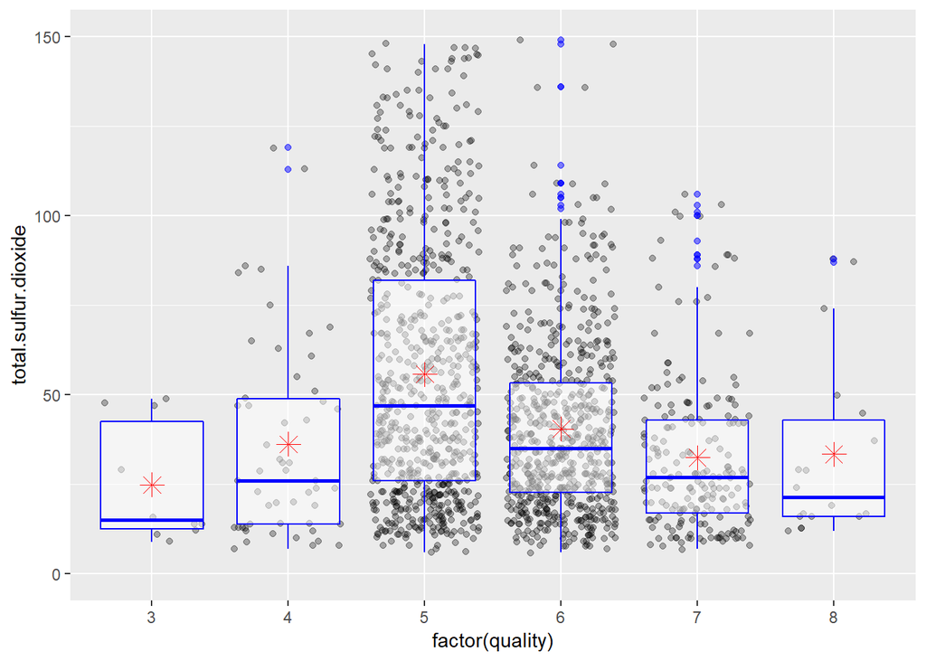

It seems the relationship between quality and free sulfur dioxid or total sulfur dioxid follow a similar pattern. Low level of free sulfur dioxide and total sulfur dioxide would produce either low quality (<= 4) or high quality (>= 7) of wine while high level would produce average quality (5 and 6) of wine.

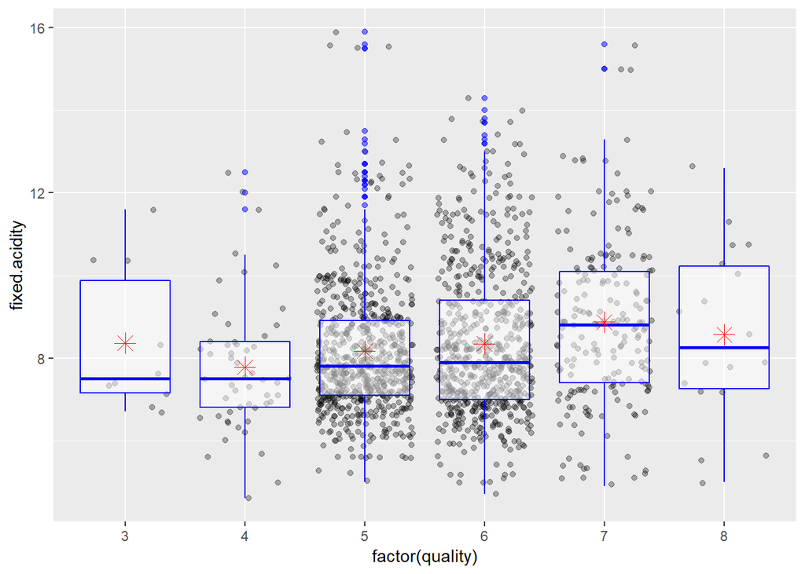

Thi plot doesn’t show a strong relationship between the quality and the amount of fixed acidity.

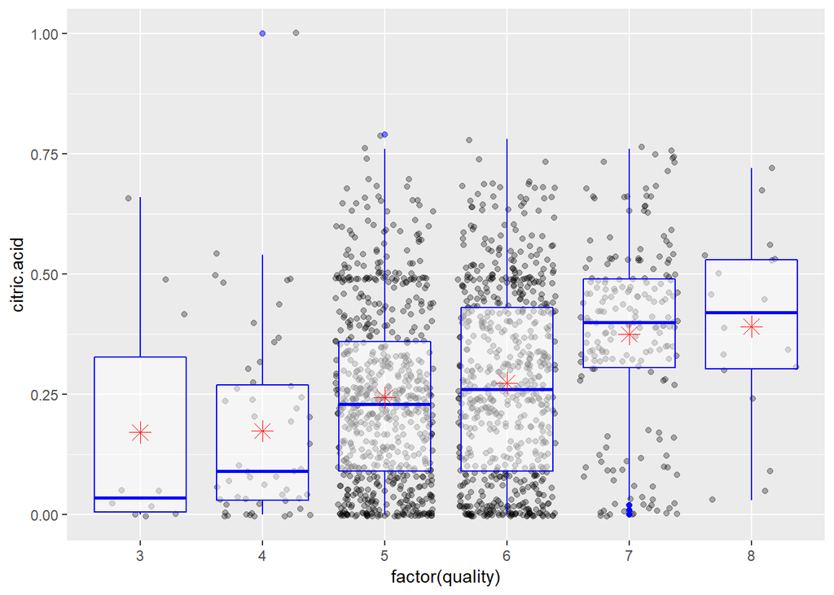

It seems better wines have higher amount of citric acid.

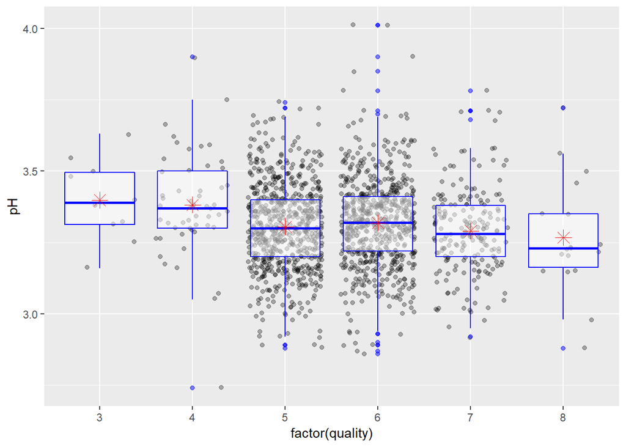

No clear relationship is observed in this plot.

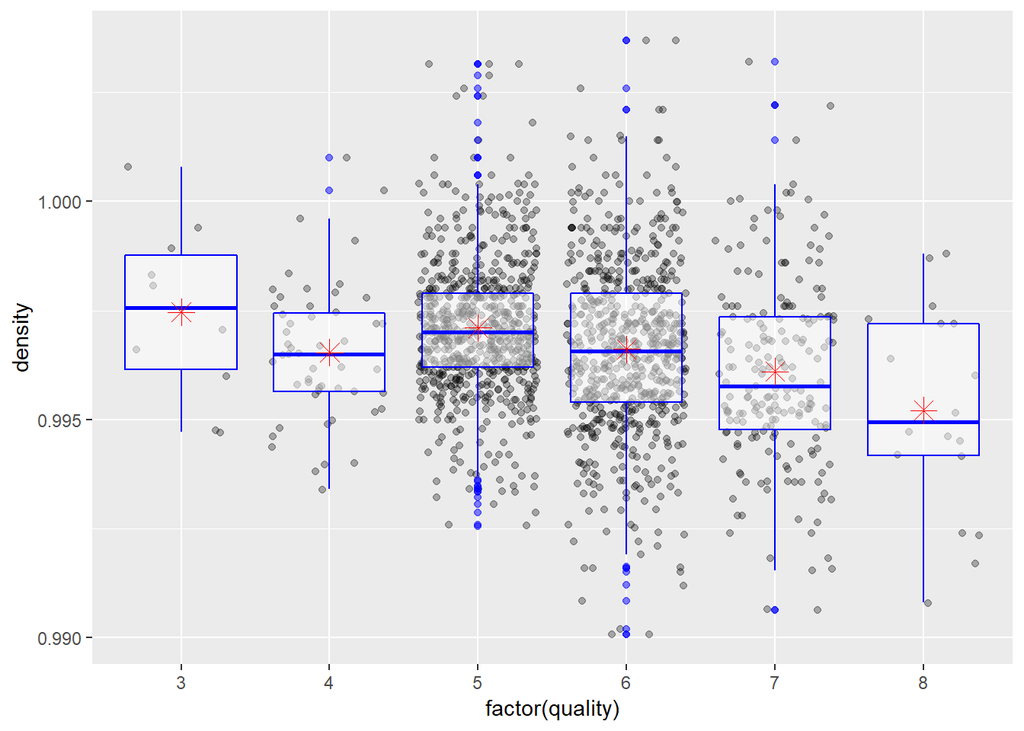

This plot seems to suggest better wines have lower density.

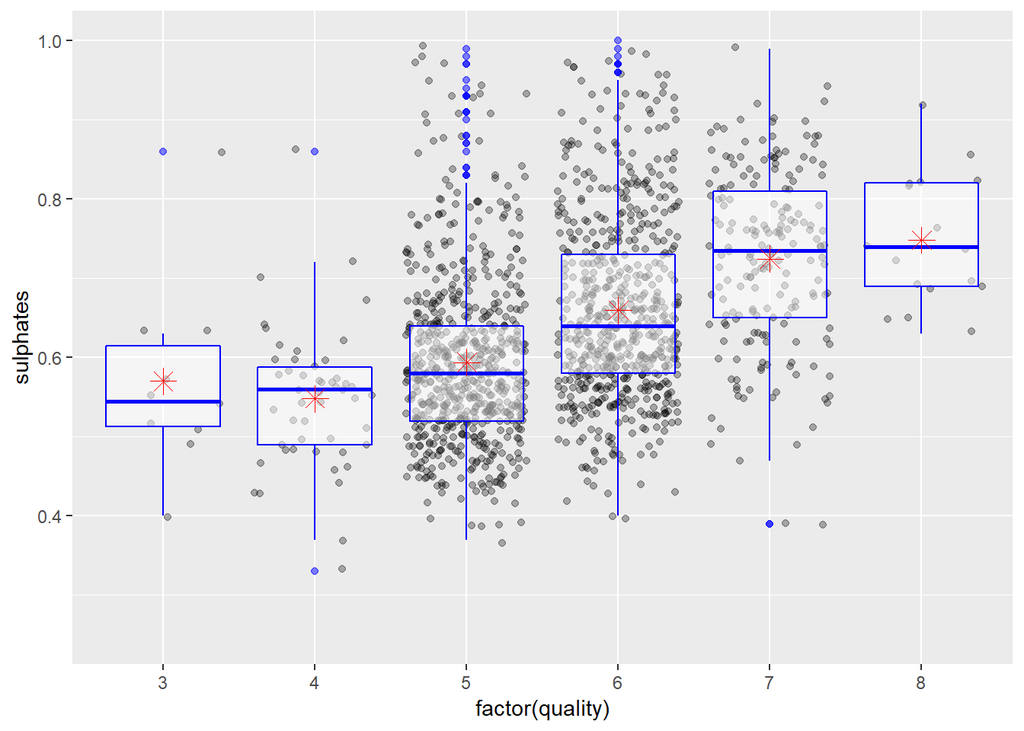

It seems better wines have high concentration of sulphates in them.

# Bivariate Analysis

No correlation coefficient is higher than 7. Among all the variables, alcohol and volatile acidity are correlated to quality the most.The correlation coefficients are 0.4762 and -0.3906.We have also observed the quality is influenced by other chemicals such as sulphates, citric acid and chlorides.However the correlations aren’t as strong as with alohol and volatile acidity.

pH is positively correlated to volatile acidity. This relationship is counterintuitive because as pH level increases, the acidity should decrease.

The strongest relationship is betwen fixed acidity and pH with a correlation coefficient of -0.683. This strong correlation makes sense because as the acidity level increases, the pH level would decrease.

# Multivariate Plots Section

Because alcohol, among all the chemicals, have the strongest corrleation with quality, we will make alcohol a constant variable here and study how its interaction with other chemicals impact the quality of wine.

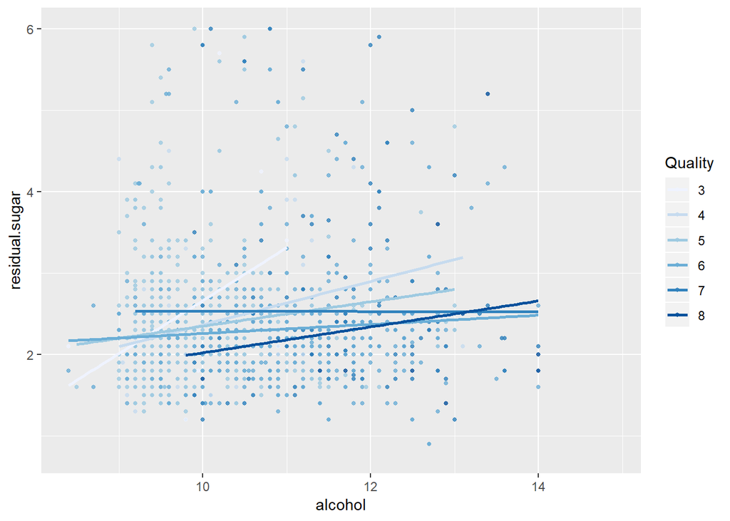

No strong relationship is observed here.

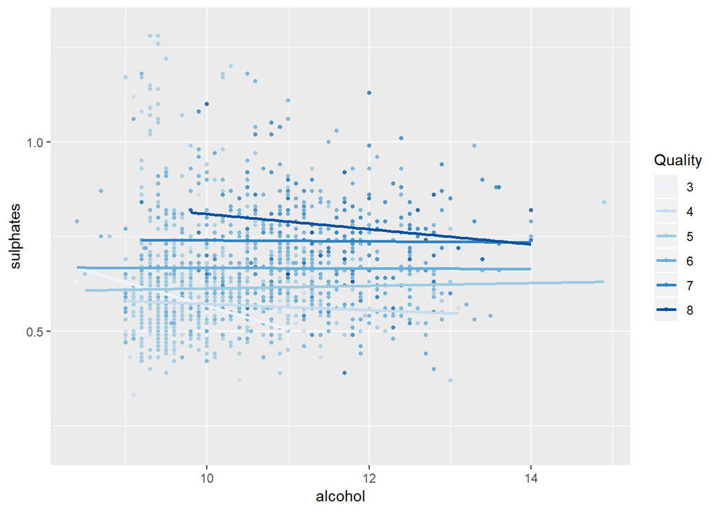

If we take the outliers out of consideration, it seems the combination of high alcohol content with high concentration of sulphtes can produce wine of better quality.

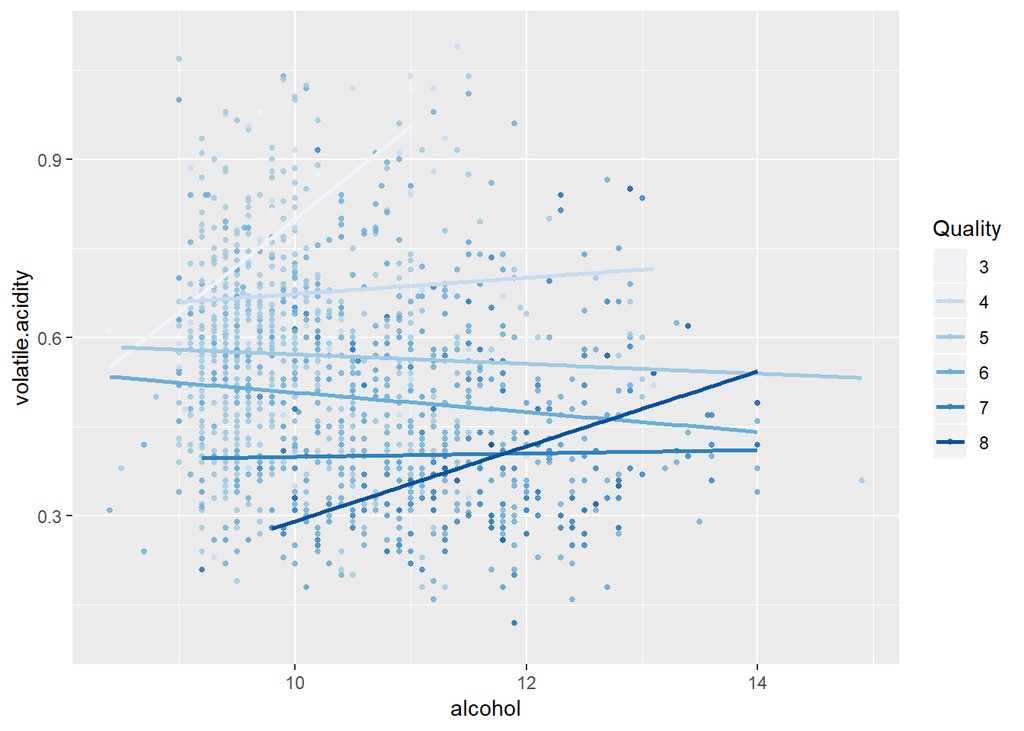

This plot shows that wines with higher quality are in the lower right section. We can therefore conclude that high alcohol concentration and low volatile acidity would produce higher quality wine.

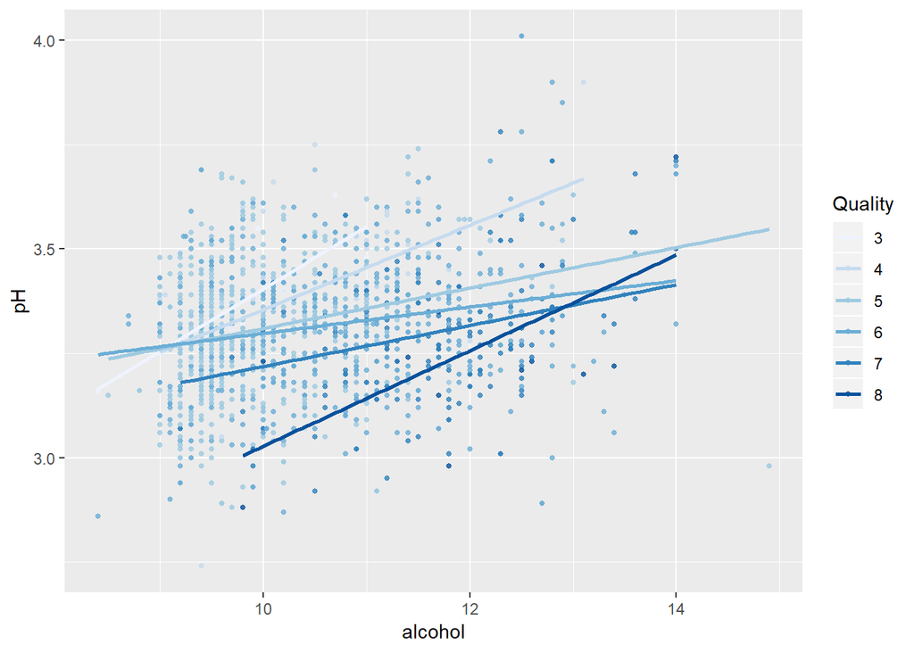

Similarly, it seems high alcohol content with low pH level would produce wine of better quality.

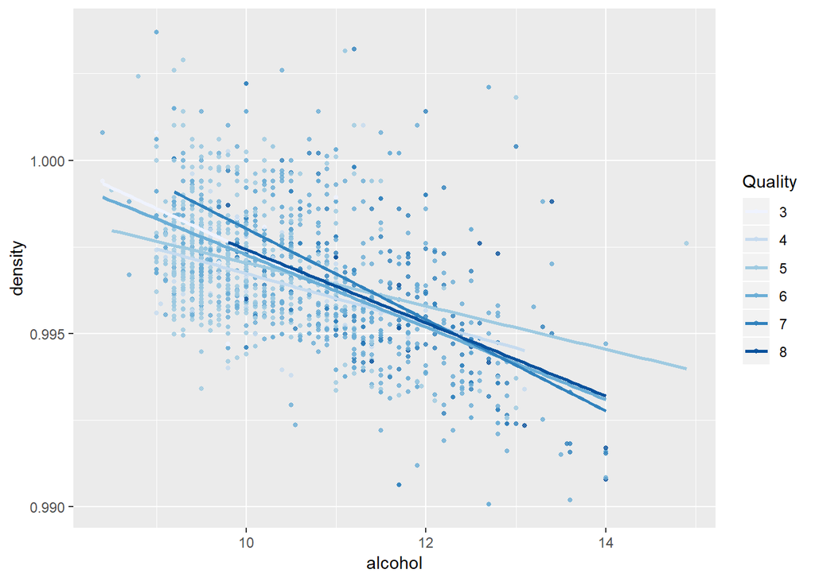

No relationship is observed here.

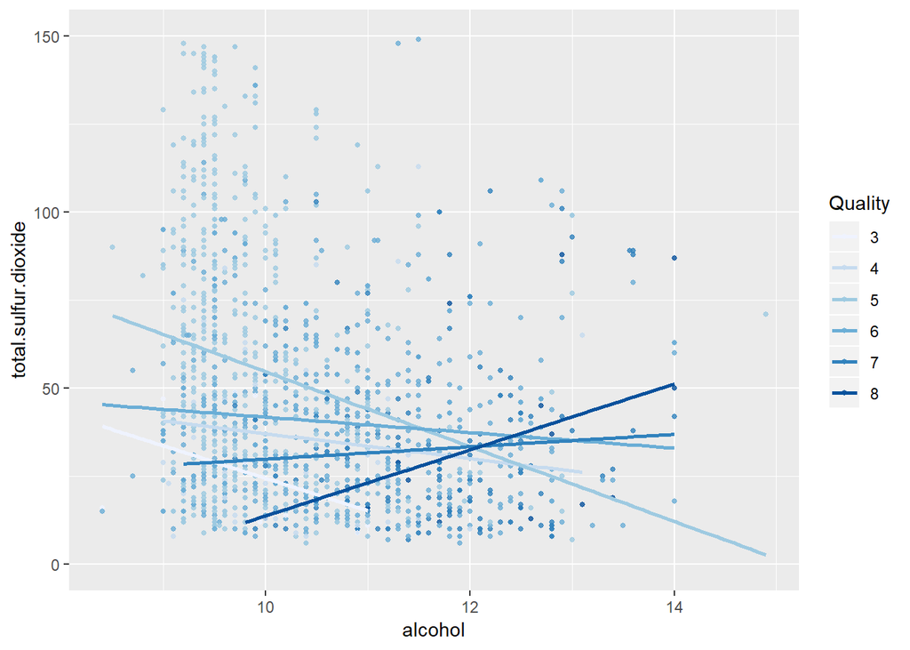

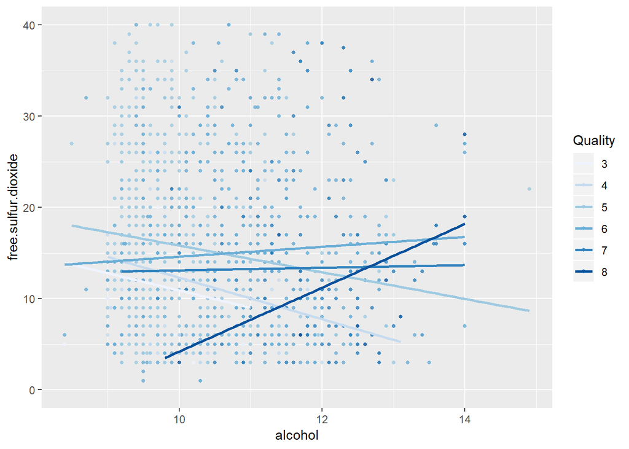

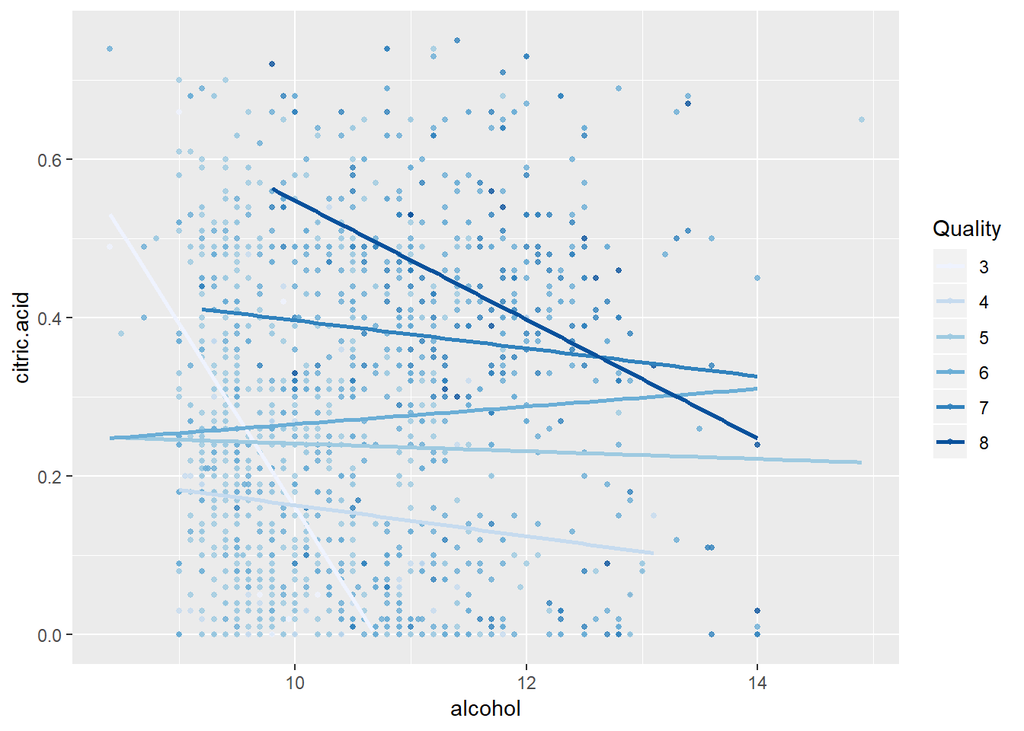

The plot shows that high quality wine is associated with higher alcohol concentration and higher citric acid level.